# Question 1

Abstract

This investigates how Africa’s experience differed from the other regions; it investgates what it means to have certain attributes as well as looks at what the implications should new vaccinations have been rolled out later.

# The main Data

The main Data that I’ll be working on are loaded in here.

```r
#loading in the main database I'll be using

owid_covid_data <- read_csv("owid-covid-data.csv")#load in the data
attach(owid_covid_data) #attach data so don't have to call it each time
```

# The African experience

Africa experienced lower deaths rates (Covid 19 deaths rates) and new cases than the other regions.

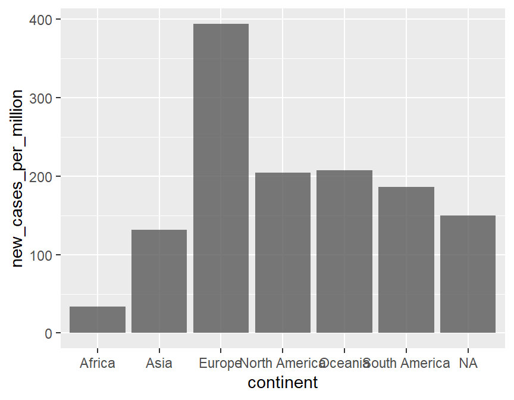

```r
#The following code summarizes evidence that is grouped by locations and continent


owid_sum<-owid_covid_data %>% group_by(continent) %>% summarise_at( vars(c(new_cases_per_million, new_deaths_per_million, total_deaths_per_million, total_deaths, total_cases, total_cases_per_million)), ~mean(.x,na.rm=T))


Owid_summarized<- owid_covid_data %>% arrange(date) %>%group_by(location, continent) %>%  summarise_at(vars(c(new_cases_per_million, new_deaths_per_million, total_deaths_per_million, hospital_beds_per_thousand, total_cases,total_cases_per_million, weekly_hosp_admissions, weekly_hosp_admissions_per_million)),~mean(.x,na.rm=T))



#Assign colours to different grouped positons
cols<-c ("blue", "orange", "purple", "gold", "pink", "green","yellow")


#Draws a barplot of owid_sum


g<-owid_sum %>% ggplot()+ geom_bar(stat="identity",aes(x=continent, y=new_cases_per_million),alpha=0.8)+
    scale_color_manual(values=cols)

g
```

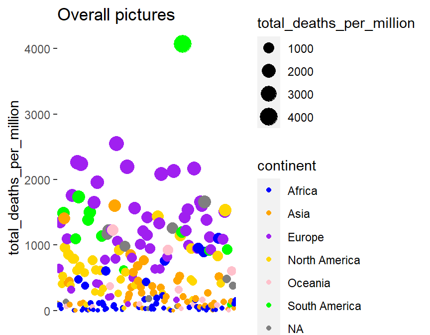

```r
#Plot the graph for total deaths

plt<-Owid_summarized%>% group_by(continent) %>%ggplot()+
    geom_point(aes(x=location, y=total_deaths_per_million,size=total_deaths_per_million, colour=continent))+
    scale_color_manual(values = cols)+
    theme(axis.title.x= element_blank(), axis.text.x =element_blank(),axis.ticks.x = element_blank(), axis.title.y = element_text("Total deaths per million"))+ ggtitle(label = "Overall pictures")


plt
```

Question: Do countries with higher life expectancy display distinct patterns in the severity of their covid-19 experience

Motivation: life expectancy is suggestive of healthy population and good medical care hence, should show tendency of lower deaths rates

Method: Distribution of death amongst those above the mean/ average life expectancy in the data and those below IT

Findings: Both have tails to the right (skewed to the right), however, those whose life expectancy are higher than the average, have a flatter distribution than those whose life expectancy are smaller.

Conclusion: I suspect it has to do something with good health care

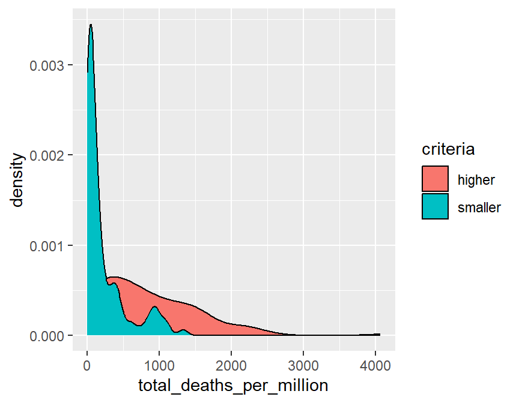

```r
#idea is what is the mean in data and work around that for each variables


#I summarized the data by their locations for the variables totcal deaths and cases and life expec
Summarized_locations<-owid_covid_data %>% group_by(location) %>%
    summarize_at(vars(c(total_cases_per_million,total_deaths_per_million, life_expectancy)),~mean(.x, na.rm=T))


#I added columns which took the mean of the life expectancy from groups and made a criteria for those who are above it and those below it
Ungrouped_mutated<-Summarized_locations %>% ungroup() %>% mutate(life_expect= mean( life_expectancy, na.rm=T)) %>%
    mutate(criteria=ifelse(life_expectancy<life_expect, "smaller", ifelse(life_expectancy>life_expect, "higher", "middle"))) %>%
    drop_na()


#Plot the graphs
Deaths<-Ungrouped_mutated %>% group_by(criteria) %>% ggplot(aes(x=total_deaths_per_million)) + geom_density(aes(fill=criteria))+
    theme(title=element_text("Total deaths per million for two groups with different life expectancy"), axis.title.x= element_text("Total deaths per million"), axis.title.y =element_text("Probabilties"))

Deaths
```